# BKA_Kriminalstatistik_2019_data_analysis

Peter von Bodelschwingh, Joshua Gawenda

12 12 2020

# German crime statistics 2019 - A data analysis

## Introduction

In this data analysis we are going to take a look at the German crime statistics from the year 2019, the special version we are looking at also shows the crime distribution about different sized cities. The data is divided for all 16 German provinces and into a general section for the whole country. + There are also multiple files that help to determine what can be deducted from a data analysis of this set and what is out of scope. + The data set is taken from the “Bundeskriminalamt” - the leading institution of crime detection in Germany. + The original data set can be found here: [BKA Dataset](https://www.bka.de/DE/AktuelleInformationen/StatistikenLagebilder/PolizeilicheKriminalstatistik/PKS2019/PKSTabellen/LandFalltabellen/landFalltabellen.html) + This data set only shows absolute numbers for all provinces in Germany, so to make the statistics comparable over all the different provinces we also included another data set, that shows the number of inhabitants for every province and the whole country. + This data set can be found here: [German Inhabitants](https://www.destatis.de/DE/Themen/Laender-Regionen/Regionales/Gemeindeverzeichnis/Administrativ/02-bundeslaender.html) + Later you will see that we imported on more data set. This one is generated out of a PDF from the documentation for the first data set and therefore is not available in the format we have online. It holds information about the so called sum keys of the main data set and is later used to decouple the main data set.

### Sum Keys

To understand a big part of the analysis you have to understand what sum keys are, this is what we are going to describe in this chapter. + A key in the data set we use represents one type of crime, every crime has its own distinct key. Some crimes are just a composite of multiple other crimes, their key is then called a sum key, so every crime that is not a sum, has no children but only a parent crime. + A key is made out of six digits, where every digit is read as a single one from left to right. In general every key that starts with the same digits is part of the same sum key, the sum key is then identified with the same starting digits followed by zeros. However this is not true in every case, some keys that end with zero have no children and therefore are no sum keys, the sum key for those keys is in most cases represented by a "*"-sign. + One general section of crimes is therefore represented by only the first digit. There are also two whole sections of keys that are only made out of sum keys and are used by the police to study different fields of crimes.

## Import

The first step to every data analysis is to import the data into your project. The data we chose is available as an excel file so we use the package “readxl” to import the sets from excel. For the import to work properly we had to remove some unnecessary header lines in the main data set, we did that by specifying a “range” in the read_excel command. + The “SumKeys” data set was created by us, therefore every optimization for importing where made while creating the set. + Finally we also import the data set for the inhabitants, since this data set is not part of the main analysis, we decided to also edit it in excel to optimize it for the import and remove data that we do not need for the analysis.

```r
originalSet <- read_excel("DataSets/PKS_crime_statistics.xlsx", sheet = "Data",range = "A8:U18777")
sumKeysImport <- read_excel("DataSets/PKS_crime_statistics.xlsx", sheet = "Sumkeys")
germanInhabitants <- read_excel("DataSets/02-bundeslaender.xlsx", sheet = "inhabitants")
```

### Renaming

After the import, the names of the original data set got lost and are not descriptive anymore. To assure that the usage later on is more understandable we renamed the data set.

```r
originalSet <- originalSet %>%
                rename(
                  key = '1',
                  crime = '2',
                  province = '3',
                  detected_cases = '4',
                  detected_cases_percent = '5',
                  not_executed_cases = '6',
                  not_executed_cases_percent = '7',
                  distribution_under_20K = '8',
                  distribution_20K_to_100K = '9',
                  distribution_100K_to_500K = '10',
                  distribution_over_500K = '11',
                  distribution_unknown = '12',
                  gun_threatened = '13',
                  gun_shot = '14',
                  solved_cases = '15',
                  solved_cases_percent = '16',
                  suspects = '17',
                  male = '18',
                  female = '19',
                  non_german ='20',
                  non_german_percent = '21'
                  )
```

As a last step of importing, we can merge the inhabitants data frame into the original data frame for the analysis. This would allow to use the number of inhabitants easily in any calculation from here on.

```r
originalSet <- merge(originalSet, germanInhabitants, by = "province") %>% arrange(key)
head(originalSet)
```

|  | province | key | crime | detected_cases | detected_cases_percent | not_executed_cases | not_executed_cases_percent | distribution_under_20K | distribution_20K_to_100K | distribution_100K_to_500K | distribution_over_500K | distribution_unknown | gun_threatened | gun_shot | solved_cases | solved_cases_percent | suspects | male | female | non_german | non_german_percent | inhabitants |
| --- | --- | --- | --- | --- | --- | --- | --- | --- | --- | --- | --- | --- | --- | --- | --- | --- | --- | --- | --- | --- | --- | --- |
| 1 | Baden-Württemberg | ------ | Straftaten insgesamt | 573813 | 100 | 48562 | 8.5 | 175726 | 207084 | 132301 | 54347 | 4355 | 274 | 325 | 348664 | 60.8 | 238737 | 182574 | 56163 | 96219 | 40.3 | 11100394 |
| 2 | Bayern | ------ | Straftaten insgesamt | 603464 | 100 | 45581 | 7.6 | 235721 | 141835 | 64933 | 129814 | 31161 | 354 | 345 | 404145 | 67.0 | 289856 | 221025 | 68831 | 121928 | 42.1 | 13124737 |
| 3 | Berlin | ------ | Straftaten insgesamt | 513426 | 100 | 41505 | 8.1 | 0 | 0 | 0 | 513426 | 0 | 342 | 316 | 229532 | 44.7 | 136704 | 100677 | 36027 | 61841 | 45.2 | 3669491 |
| 4 | Brandenburg | ------ | Straftaten insgesamt | 171828 | 100 | 11278 | 6.6 | 81968 | 64415 | 24717 | 0 | 728 | 88 | 124 | 96690 | 56.3 | 65374 | 49299 | 16075 | 16303 | 24.9 | 2521893 |
| 5 | Bremen | ------ | Straftaten insgesamt | 78228 | 100 | 7288 | 9.3 | 0 | 0 | 12020 | 65869 | 339 | 67 | 43 | 38118 | 48.7 | 24101 | 18108 | 5993 | 9599 | 39.8 | 681202 |
| 6 | Bundesrepublik Deutschland | ------ | Straftaten insgesamt | 5436401 | 100 | 416594 | 7.7 | 1243451 | 1451426 | 1061629 | 1569157 | 110738 | 4512 | 4639 | 3124161 | 57.5 | 2019211 | 1514667 | 504544 | 699261 | 34.6 | 83166711 |

## Tidy

This next step includes checking for missing values and in our case splitting the data frames up, so that the provinces are decoupled from the values for whole Germany. We also need to remove all sum keys from the actual capture keys.

### Check non NA

If the data set contains empty values they are marked as NA and have to be handled somehow. However, this data set has no such values as shown in the next code chunk. Here we filter for NA values in any column and check if the row count is 0 in the end.

```r
nrow(filter_at(originalSet, 1:21, any_vars(is.na(.)))) == 0
```

```
## [1] TRUE
```

### Decouple

Like describe in the “Sum Key” section, the original data set is a mix of sum keys and capture keys. In order to not count twice in some operations we remove the sum keys from the capture keys, so the main analysis can focus on the capture keys. + The sum keys set that we imported has two columns, one for the key and one with the value “Y” for every capture key and a “N” for every sum key. The two key sections that are only made out of sum keys are not reported in the set, so can be handled as “NA”.

```r
captureKeys <- sumKeysImport %>% filter(grepl("Y",is_sum_key))
sumKeys <- sumKeysImport %>% filter(!grepl("Y",is_sum_key))
```

To check, that the keys after the filter are all correct, we created a small algorithm that checks for sum keys based on the the rules described in the “Sum Keys” chapter. The code takes a while to run, that is why we saved the result in a vector.

```r
#filteredKeys <- c()
#for (key1 in captureKeys$key) {
#  if (!key1 %in% filteredKeys) {
#    for (key2 in captureKeys$key) {
#      if (!key2 %in% filteredKeys) {
#        if (key1 != key2) {
#          if (regexpr(paste("^", str_remove(key2, "0+$"), sep = ""), key1)[1] == 1) {
#            filteredKeys <- append(filteredKeys, key2)
#          }
#        }
#      }
#    }
#  }
#}
filteredKeys <- c("133000","141100","231200","305000","310000","315000","325000","326000","335000","340000","345000","350000","390000","435000","436000","620010","655010","670010","670020","670030")
```

After checking the resulting keys manually we found, that the keys “141100”, “231200” and “133000” were marked as capture keys, but are sum keys, so these keys have to be removed from the capture keys and added to the sum keys.

```r
captureKeys <- sumKeysImport %>% filter(grepl("Y",is_sum_key) & !(key %in% c("141100","231200","133000")))
sumKeys <- sumKeysImport %>% filter(!grepl("Y",is_sum_key) | (key %in% c("141100","231200","133000")))
```

### Filter final data frames

First to reduce duplicate data, we filtered out all crime descriptions into its own data frame, to it can be looked up afterwards.

```r
crimeOverview <- originalSet %>% select(key, crime) %>% unique()
crimeOverview <- arrange(crimeOverview, key)
head(crimeOverview)
```

|  | key | crime |
| --- | --- | --- |
| 1 | ------ | Straftaten insgesamt |
| 2 | ****00 | Diebstahl insgesamt und zwar: |
| 3 | ***100 | Diebstahl insgesamt von Kraftwagen einschl. unbefugte Ingebrauchnahme |
| 4 | ***200 | Diebstahl insgesamt von Mopeds und Krafträdern einschl. unbefugte Ingebrauchnahme |
| 5 | ***300 | Diebstahl insgesamt von Fahrrädern einschl. unbefugte Ingebrauchnahme |
| 6 | ***400 | Diebstahl insgesamt von Schusswaffen |

```r
originalSet <- originalSet %>% select(!crime)
```

## Transform

In the final step before visualizing the data we need to check all the types of the values in each column an change them to a type that is usable for our analysis. We can also remove and create new Columns if necessary. In the end we are also splitting the original data frame up based on the provinces and the sum keys determined before.

### Transforming data types

In this step we first check for the different data types we have in every column. We expect to have characters as the key, a factor for the provinces and every other column should be a number.

```r
sapply(originalSet, class)
```

```
##                   province                        key
##                "character"                "character"
##             detected_cases     detected_cases_percent
##                  "numeric"                  "numeric"
##         not_executed_cases not_executed_cases_percent
##                  "numeric"                  "numeric"
##     distribution_under_20K   distribution_20K_to_100K
##                  "numeric"                  "numeric"
##  distribution_100K_to_500K     distribution_over_500K
##                  "numeric"                  "numeric"
##       distribution_unknown             gun_threatened
##                  "numeric"                  "numeric"
##                   gun_shot               solved_cases
##                  "numeric"                  "numeric"
##       solved_cases_percent                   suspects
##                  "numeric"                  "numeric"
##                       male                     female
##                  "numeric"                  "numeric"
##                 non_german         non_german_percent
##                  "numeric"                  "numeric"
##                inhabitants
##                  "numeric"
```

Except for the province all values have the type expected, the next step is to transform the province into a factor.

```r
originalSet$province <- as.factor(originalSet$province)
sapply(originalSet, class)
```

```
##                   province                        key
##                   "factor"                "character"
##             detected_cases     detected_cases_percent
##                  "numeric"                  "numeric"
##         not_executed_cases not_executed_cases_percent
##                  "numeric"                  "numeric"
##     distribution_under_20K   distribution_20K_to_100K
##                  "numeric"                  "numeric"
##  distribution_100K_to_500K     distribution_over_500K
##                  "numeric"                  "numeric"
##       distribution_unknown             gun_threatened
##                  "numeric"                  "numeric"
##                   gun_shot               solved_cases
##                  "numeric"                  "numeric"
##       solved_cases_percent                   suspects
##                  "numeric"                  "numeric"
##                       male                     female
##                  "numeric"                  "numeric"
##                 non_german         non_german_percent
##                  "numeric"                  "numeric"
##                inhabitants
##                  "numeric"
```

### Remove calculated columns

Some columns in the data set are just calculated from the given data, so to remove the possibility of a calculation error, we remove these columns and add them on our own, once they are needed in the analysis.

```r
originalSet <- originalSet %>% select(key, province, inhabitants, detected_cases, solved_cases, not_executed_cases, suspects, male, female, non_german, gun_threatened, gun_shot, distribution_under_20K, distribution_20K_to_100K, distribution_100K_to_500K, distribution_over_500K, distribution_unknown)
```

### Split up data

This could also be part of the tidy step, but to reduce the amount of duplicate code for all checks, we split the data at the end. Therefore, we merge both key frames together with the original data set to separate the sum keys and the capture keys into separate data frames.

```r
captureValues <- merge(originalSet, captureKeys) %>% select(!is_sum_key)
sumValues <- merge(originalSet, sumKeys) %>% select(!is_sum_key)
```

With the sum keys now separated, we also divide both data frames into the values for the provinces and the values for whole Germany.

```r
germanCaptureSet <-
  captureValues %>% filter(grepl("Bundesrepublik Deutschland", province))
provinceCaptureSet <-
  captureValues %>% filter(!grepl("Bundesrepublik Deutschland", province))

germanSumSet <-
  sumValues %>% filter(grepl("Bundesrepublik Deutschland", province))
provinceSumSet <-
  sumValues %>% filter(!grepl("Bundesrepublik Deutschland", province))
```

To check that the sum keys from before where separated correct we check that the sum of all detected cases in each German set is equal to the sum for the detected cases in the province set.

```r
sum(germanCaptureSet$detected_cases) == sum(provinceCaptureSet$detected_cases)
```

```
## [1] TRUE
```

```r
sum(germanSumSet$detected_cases) == sum(provinceSumSet$detected_cases)
```

```
## [1] TRUE
```

## Visualise

```r
options(scipen=999)
```

[figure not shown]

```r
plot(germanCaptureSet)
```

```r
filter(crimeOverview, key == "731800")
```

| key | crime |
| --- | --- |
| 731800 | Allgemeiner Verstoß mit Cannabis und Zubereitungen |

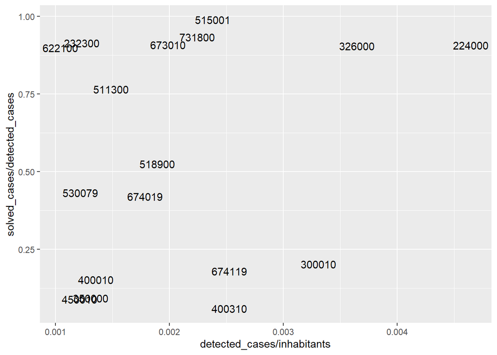

```r
ggplot(
  data = filter(germanCaptureSet, detected_cases/inhabitants > 0.001),
  mapping = aes(detected_cases/inhabitants, solved_cases/detected_cases)) +
  #geom_point() +
  #geom_smooth(method="lm")
  geom_text(mapping = aes(label = key))
```